# Object Oriented Programming

Alan Arnholt

Last updated: Feb 29, 2016

## R Themes[^1]

- Everything you touch in R - ranging from numbers to character strings to matrices - is an object.
- R promotes *encapsulation*, which is packaging separate but related data items into one class instance. Encapsulation helps you keep track of related variables, enhancing clarity.
- R classes are *polymorphic*, which means that the same function call leads to different operations for objects of different classes. For instance, a call to `print()` on an object of a certain class triggers a call to a print function tailored to that class. Polymorphism promotes usability.

## S3 Classes

An S3 class consists of a list, with a class name attribute and *dispatch* capability added.

- `class` is an attribute of an object that dictates what message the object can receive and return.
- `method` is a function that is designed for a specific class.
- `dispatch` is selection of the class specific method.

## S3 Generic Functions

When a generic function is called, R will dispatch the call to the proper class method, meaning that it will reroute the call to a function defined for the object’s class.

1. A generic function (`plot`, `print`, `summary`, etc.) checks the class of the object.
2. A search is done to see if there is an appropriate method for that class.
3. If there exists a method for that class, then that method is called on the object and we are finished.
4. If a method for a class does not exist, a search is done to see if there is a `default` method for the generic function. If `default` exists, then it is called.
5. If no default exists an error appears.

```r
plot
```

```
function (x, y, ...)
UseMethod("plot")
<bytecode: 0x24027b8>
<environment: namespace:graphics>
```

Note that the generic function `plot` has `UseMethod("plot")` in its function call. To see all implementations of a generic function type `methods(GenericFunction)`.

```r
methods(plot)
```

```
 [1] plot.acf*           plot.data.frame*    plot.decomposed.ts*
 [4] plot.default        plot.dendrogram*    plot.density*
 [7] plot.ecdf           plot.factor*        plot.formula*
[10] plot.function       plot.hclust*        plot.histogram*
[13] plot.HoltWinters*   plot.isoreg*        plot.lm*
[16] plot.medpolish*     plot.mlm*           plot.ppr*
[19] plot.prcomp*        plot.princomp*      plot.profile.nls*
[22] plot.raster*        plot.spec*          plot.stepfun
[25] plot.stl*           plot.table*         plot.ts
[28] plot.tskernel*      plot.TukeyHSD*
see '?methods' for accessing help and source code
```

One way to view the code for a hidden method (one that ends with `*`) is to use the `getAnywhere` function.

```r
getAnywhere(plot.density)
```

```
A single object matching 'plot.density' was found
It was found in the following places
  registered S3 method for plot from namespace stats
  namespace:stats
with value

function (x, main = NULL, xlab = NULL, ylab = "Density", type = "l",
    zero.line = TRUE, ...)
{
    if (is.null(xlab))
        xlab <- paste("N =", x$n, "  Bandwidth =", formatC(x$bw))
    if (is.null(main))
        main <- deparse(x$call)
    plot.default(x, main = main, xlab = xlab, ylab = ylab, type = type,
        ...)
    if (zero.line)
        abline(h = 0, lwd = 0.1, col = "gray")
    invisible(NULL)
}
<bytecode: 0x2264620>
<environment: namespace:stats>
```

## Writing S3 Classes

A class instance is created by forming a list, with the components of the list being the member variables of the class. The `class` attribute is set by hand using the `class` function, and then various implementations of generic functions are defined. Consider the following slightly modified code taken from *S Programming* for a 2 sample equal variance t-test.

Recall that the formula for the 2 sample equal variance t-test is:

$t_{obs} = \frac{(\bar{x} - \bar{y}) - (\mu_x - \mu_y)}{\sqrt{1/n_x + 1/n_y}\cdot \sqrt{\left((n_x-1)\cdot s_x^2 + (n_y-1)\cdot s_y^2)\right)/(n_x + n_y - 2)}} \sim t_{n_x + n_y -2}$

```r
ttest <- function(x, y, alpha = 1/20, alternative = "two.sided", ...){
  if(is.null(class(x))){
    class(x) <- data.class(x)
  }
  UseMethod("ttest")
}
```

The `ttest.default` is written next. Note that a list (`results`) is constructed and the given the class `my.t.test` with the code `class(results) <- "my.t.test"`.

```r
ttest.default <- function(x, y, alpha = 1/20, alternative = "two.sided", ...){
  choices <- c("two.sided", "greater", "less")
  alt <- pmatch(alternative, choices)
  alternative <- choices[alt]
  # add some checks here
  yok <- !is.na(y)
  xok <- !is.na(x)
  x <- x[xok]
  y <- y[yok]
  n1 <- length(x)
  n2 <- length(y)
  ndf <- n1 + n2 - 2
  s2 <- ((n1 - 1)*var(x) + (n2 - 1)*var(y))/ndf
  tstat <- (mean(x) - mean(y))/sqrt(s2*(1/n1 + 1/n2))
  # tails
  if(alternative == "two.sided"){
    tail.area <- 2 * (1 - pt(abs(tstat), ndf))
  } else if(alternative == "less") {
    tail.area <- pt(tstat, ndf)
  } else {
    tail.area <- 1 - pt(tstat, ndf)
  }
  results <- list("t-stat" = tstat, d.f. = ndf, y1 = x, y2 = y,
                  alternative = alternative, tail.area = tail.area,
                  reject = tail.area < alpha, alpha = alpha)
  class(results) <- "my.t.test"
  results
}
```

Objects of class `my.t.test` will be printed using the generic `print` after defining `print.my.t.test`.

```r
print.my.t.test <- function(x, ...){
  cat("\n")
  cat("My Monday Night Modified 2 Sample Equal Variance t-test", "\n")
  cat("\n")
  cat(paste("Alternative hypothesis:", x[5]), "\n")
  cat(paste("Reject the null hypothesis:", x[7]), "\n")
  cat("\n")
  print(round(unlist(x[c(1, 2, 6)]), 4))
  invisible(x)
}
```

Objects of class `my.t.test` will be plotted using the generic `plot` after defining `plot.my.t.test`.

```r
plot.my.t.test <- function(x, ...){
  boxplot(x[c("y1", "y2")], col = "pink",
          names = c("Sample 1", "Sample 2"), ...)
}
```

Additional methods

```r
ttest.matrix <- function(x, ...){
  ttest(x[, 1], x[, 2])
}

ttest.list <- function(x, ...){
  ttest(x = x[[1]], y = x[[2]])
}
```

## Does This Work?

```r
set.seed(123)
TT <- ttest(rnorm(100, 0, 1), rnorm(100, 1, 1))
TT
```

```
My Monday Night Modified 2 Sample Equal Variance t-test

Alternative hypothesis: two.sided
Reject the null hypothesis: TRUE

   t-stat      d.f. tail.area
  -6.0315  198.0000    0.0000
```

```r
print(TT)
```

```
My Monday Night Modified 2 Sample Equal Variance t-test

Alternative hypothesis: two.sided
Reject the null hypothesis: TRUE

   t-stat      d.f. tail.area
  -6.0315  198.0000    0.0000
```

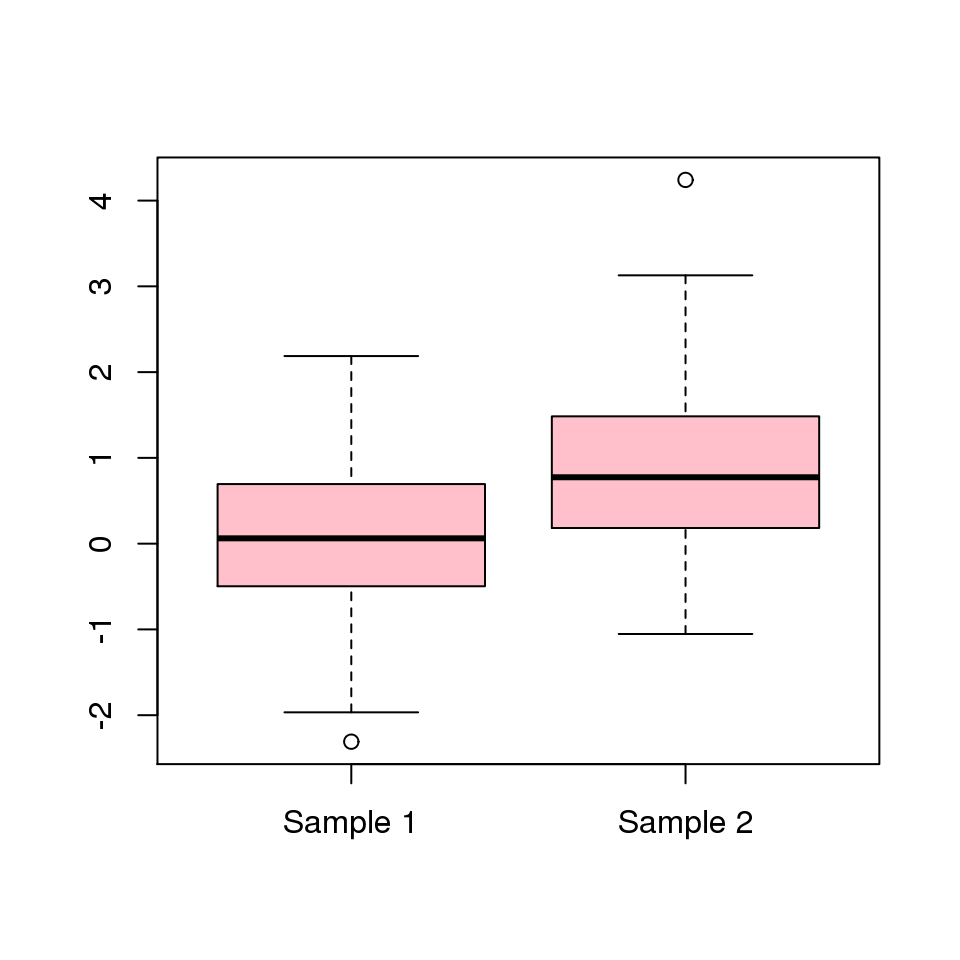

```r
plot(TT)
```

```r
Mx1x2 <- matrix(rnorm(60, 0, 1), nrow = 30)
class(Mx1x2)
```

```
[1] "matrix"
```

```r
TM <- ttest(Mx1x2)
TM
```

```
My Monday Night Modified 2 Sample Equal Variance t-test

Alternative hypothesis: two.sided
Reject the null hypothesis: FALSE

   t-stat      d.f. tail.area
   0.3348   58.0000    0.7390
```

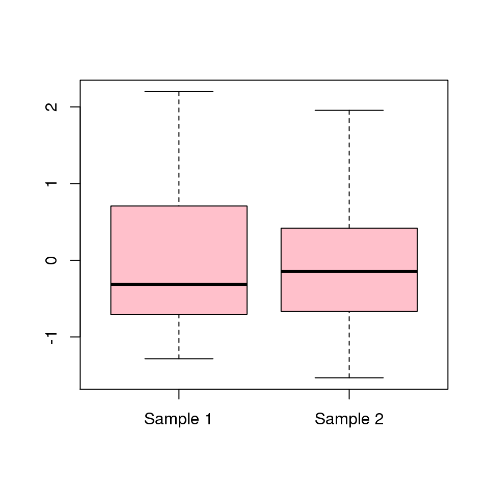

```r
plot(TM)
```

```r
mylist <- list(xl = rnorm(30), yl = rnorm(30))
class(mylist)
```

```
[1] "list"
```

```r
ttest(mylist)
```

```
My Monday Night Modified 2 Sample Equal Variance t-test

Alternative hypothesis: two.sided
Reject the null hypothesis: FALSE

   t-stat      d.f. tail.area
  -0.0529   58.0000    0.9580
```

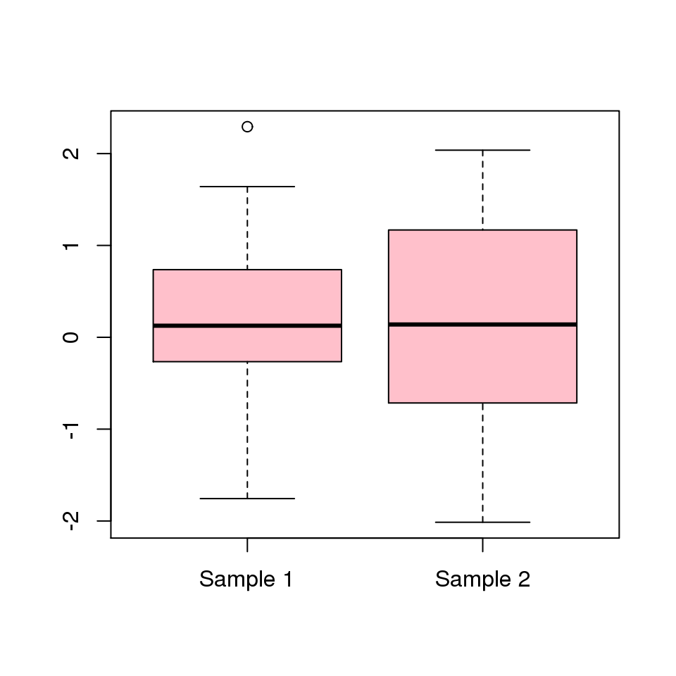

```r
plot(ttest(mylist))
```

## How To Package?

What does the `ttest.R` file with `roxygen` look like?

```
#' Two-Sample Equal Variance t-Test
#'
#' @param x a non-empty numeric vector.
#' @param y a non-empty numeric vector.
#' @param alpha value to test hypothesis.
#' @param alternative hypothesis (can take on one of three values).
#' @param ... further arguments to be passed to or from methods.
#'
#' @return the answers!
#' @export
#'
#' @examples
#' T1 <- ttest(x = rnorm(300.5, 1), y = rnorm(30, 1, 1), alternative = "less")
#' T1
#' print(T1)
#' plot(T1)
#' Mx1x2 <- matrix(rnorm(60, 0, 1), nrow = 30)
#' class(Mx1x2)
#' TM <- ttest(x = Mx1x2)
#' TM
#' plot(TM)
#' ttest(x = Mx1x2) # Test that a matrix will work
#' mylist <- list(xl = rnorm(30), yl = rnorm(30))
#' class(mylist)
#' ttest(x = mylist, alternative = "greater")
#' plot(ttest(mylist))
#'
ttest <- function(x, y, alpha = 1/20, alternative = "two.sided", ...){
  if(is.null(class(x))){
    class(x) <- data.class(x)
  }
  UseMethod("ttest")
}



#' @export
ttest.default <- function(x, y, alpha = 1/20, alternative = "two.sided", ...){
  choices <- c("two.sided", "greater", "less")
  alt <- pmatch(alternative, choices)
```

[output cut: 38 more lines]

```
#' @export
plot.my.t.test <- function(x, ...){
  boxplot(x[c("y1", "y2")], col = "pink",
          names = c("Sample 1", "Sample 2"), ...)
}

#' @export
ttest.matrix <- function(x, ...){
  ttest(x[, 1], x[, 2])
}

#' @export
ttest.list <- function(x, ...){
  ttest(x = x[[1]], y = x[[2]])
}
```

Note: I documented the function `ttest` and exported `ttest` to the `namespace` using the tag `export`. The various methods for `ttest` are exported using the `@export` tag but are not documented (my choice).

```r
methods(ttest)
```

```
[1] ttest.default ttest.list    ttest.matrix
see '?methods' for accessing help and source code
```

```r
methods(print)[111:120]
```

```
 [1] "print.ls_str"            "print.medpolish"
 [3] "print.MethodsFunction"   "print.mtable"
 [5] "print.my.t.test"         "print.NativeRoutineList"
 [7] "print.news_db"           "print.nls"
 [9] "print.noquote"           "print.numeric_version"
```

```r
methods(plot)
```

```
 [1] plot.acf*           plot.data.frame*    plot.decomposed.ts*
 [4] plot.default        plot.dendrogram*    plot.density*
 [7] plot.ecdf           plot.factor*        plot.formula*
[10] plot.function       plot.hclust*        plot.histogram*
[13] plot.HoltWinters*   plot.isoreg*        plot.lm*
[16] plot.medpolish*     plot.mlm*           plot.my.t.test
[19] plot.ppr*           plot.prcomp*        plot.princomp*
[22] plot.profile.nls*   plot.raster*        plot.spec*
[25] plot.stepfun        plot.stl*           plot.table*
[28] plot.ts             plot.tskernel*      plot.TukeyHSD*
see '?methods' for accessing help and source code
```

```r
getAnywhere(print.my.t.test)
```

```
A single object matching 'print.my.t.test' was found
It was found in the following places
  .GlobalEnv
  registered S3 method for print
with value

function(x, ...){
  cat("\n")
  cat("My Monday Night Modified 2 Sample Equal Variance t-test", "\n")
  cat("\n")
  cat(paste("Alternative hypothesis:", x[5]), "\n")
  cat(paste("Reject the null hypothesis:", x[7]), "\n")
  cat("\n")
  print(round(unlist(x[c(1, 2, 6)]), 4))
  invisible(x)
}
```

[^1]: The Art of R Programming